# Case Study Structure

Chor Fung Yeung

2024-12-30

$\\ \\ \\ \\$

## Google Data Analytics Professional Certficate

$\\ \\ \\ \\$

##### Course 8 - Google Data Analytics Capstone- Complete a Case Study

$\\$

##### Case Study 2: How Can a Wellness Technology Company Play It Smart?

$\\ \\ \\ \\$  
This is a detailed case study structure and Brainstorm records.

$\\ \\ \\ \\$

#### 1. Ask

##### Who are the stakeholders?

- The cofounder and Chief Creative Office Urška Sršen of the company BellaBeat:
  - Sršen used her background as an artist to develop beautifully designed technology that informs and inspires women around the world.
  - She asks me to analyze data.
  - Assume she is not too familiar with numbers.
- Marketing Analytic Team:
  - My fellow colleagues.
  - Compelling on figures and statistical concepts.  
    $\\$
- Conclusion: Need to generate an analytic report that explains the complex story at a simple level.  
  $\\ \\$

##### What is the business task?

- Sršen knows Bellabeat’s available consumer data would reveal more opportunities for growth.
- Use trend of smart device usages data to give high-level recommendations.
- Focus on a Bellabeat product: Bellabeat app, Leaf, Time, Spring and Bellabeat Membership. $\\ \\$

#### 2. Prepare

##### Data Source and storage

- Sršen encourages me to utilize public data of smart device users’ daily habits.
- Source: [Kaggle](https://www.kaggle.com/)
- Creditability: License: [CC0: Public Domain](https://creativecommons.org/publicdomain/zero/1.0/)
- ROCCC:
  - Reliable: Data obtained on Kaggle, a renowned public data source.
  - Original: Originally generated by respondents to a distributed survey via Amazon Mechanical Turk
  - Comprehensive: High-Quality Noteboooks
  - Current: Data period between 03.12.2016-05.12.2016. Not an issue as this is a case study.
  - Cited: [FitBit Fitness Tracker Data](https://www.kaggle.com/datasets/arashnic/fitbit), [Mobius](https://www.kaggle.com/arashnic)
- Data integrity verification can be found on [FitBit Fitness Tracker Data](https://www.kaggle.com/datasets/arashnic/fitbit).
- Data organized into 31 csv tables. All are in long format.
- Tables are divided into 2 folders, some of those dated from 03.12.2016 to 04.11.2016 (I call it the March folder), the other from 04.12.2016 to 05.12.2016 (I call it the April folder.)
- Data Storage: My Drive
- Possible issues with the data:
  - The dataset are not consistent. Some of them shows particular measures while some are merged with other.
  - Some hourly and daily files in the April folder do not exist in the March folder.
  - I consider re-organize the minutely sleep time data into daily in the March folder to match with the one in the April folder to identify possible trends.
  - The data does not specify the gender and age of the users. We can guess from the calorie burn data which a comparison with the overall average in real world. But I do not think this is very useful as the dataset only contains data of some tens of users. So let’s assume the data is unbiased.
- Sorting and Filtering.  
  $\\ \\$

#### 3. Process

##### Tools chosen and reasons

- Processing: R; handy, flexible and fast for data cleaning.
- Analyzing: R; handy, flexible and fast for analysis.
- Visualization: R and Tableau; R: handy; Tableau: Interactive

##### Integrity verification methodology:

- Check the schema of the database;
- And use the below codes to verify:

First we load the essential libraries:  
##### Load essential libraries

```r
library(tidyverse)
```

```r
library(dplyr)
library(readr)
library(ggplot2)
```

$\\ \\$ ##### Cleaning data

I will go through all data cleaning process corresponding to the below 3 pillars:  
* Accurate: The data should not contain any value that is illogical, for example, negative weight.  
* Complete: Although it’s not possible to get the users to track their every activity, we should be aware of how the activities are recorded.  
* Consistent: Making sure the unit of each feature is consistent.

After repeating the process for one month data, I will continue on the other.

$\\$

##### Documentation of Data Cleaning:

- Will log as R_data_cleaning_R.rmd  
  $\\$

Issues found in the datasets during data-cleaning:

- The dataset of dailyActivityMerged.csv of the March folder is valid.
  - However, I also find some users who do not use the device (SedentaryMinutes = 1440, See ## 1 in Appendix of R_data_cleaning.rmd) on some days. I am not filtering them out for now as they may be my target. I will address it on the Act Phase.
  - The WeightLoginfo.csv has an issue: The number of active trackers is only 11 and 8 in March and April respectively (overlapping may occur), way less than the number in the master dataset. I will also leave it for later analysis (## 2).
  - 24 out of 33 users track their sleeping time. This does not necessarily impose significant analytic problem but yet to discuss more in our action phase (## 3).
  - Date format of the weightLogInfo_merged Table has to be fixed. I will do it in R environment.

$\\ \\$

#### 4. Analysis

- Data Organization:
  - In the data-cleaning phase, we have merged the dailyActivity_merged tables (I call them master tables) of the two months as combined_data, the weightLogInfo_merged tables of them as combined_weight, and created a news table master_and_sleep that combines the April’s sleeping data with the same month’s master data (as we do not have the daily sleeping data of March). We now read them to analyze.

```r
combined_data <- read_csv("combined_data.csv")
combined_weight <- read_csv("combined_weight.csv")
april_daily_sleep <- read_csv("april_daily_sleep.csv")
master_and_sleep <- read_csv("master_and_sleep.csv")
```

- Now let’s look at the aggregates of the cleaned datasets.

```r
summary(combined_data)
```

```
##        Id             ActivityDate          TotalSteps    TotalDistance
##  Min.   :1.504e+09   Min.   :2016-03-12   Min.   :    0   Min.   : 0.000
##  1st Qu.:2.320e+09   1st Qu.:2016-04-08   1st Qu.: 3108   1st Qu.: 2.140
##  Median :4.445e+09   Median :2016-04-19   Median : 6910   Median : 4.900
##  Mean   :4.782e+09   Mean   :2016-04-19   Mean   : 7247   Mean   : 5.194
##  3rd Qu.:6.962e+09   3rd Qu.:2016-04-30   3rd Qu.:10538   3rd Qu.: 7.480
##  Max.   :8.878e+09   Max.   :2016-05-12   Max.   :36019   Max.   :28.030
##  TrackerDistance  LoggedActivitiesDistance VeryActiveDistance
##  Min.   : 0.000   Min.   :0.0000           Min.   : 0.000
##  1st Qu.: 2.110   1st Qu.:0.0000           1st Qu.: 0.000
##  Median : 4.900   Median :0.0000           Median : 0.080
##  Mean   : 5.167   Mean   :0.1286           Mean   : 1.381
##  3rd Qu.: 7.440   3rd Qu.:0.0000           3rd Qu.: 1.810
##  Max.   :28.030   Max.   :6.7271           Max.   :21.920
##  ModeratelyActiveDistance LightActiveDistance SedentaryActiveDistance
##  Min.   :0.0000           Min.   : 0.00       Min.   :0.000000
##  1st Qu.:0.0000           1st Qu.: 1.58       1st Qu.:0.000000
##  Median :0.1900           Median : 3.23       Median :0.000000
##  Mean   :0.5417           Mean   : 3.18       Mean   :0.001733
##  3rd Qu.:0.7800           3rd Qu.: 4.68       3rd Qu.:0.000000
##  Max.   :6.4800           Max.   :12.51       Max.   :0.110000
##  VeryActiveMinutes FairlyActiveMinutes LightlyActiveMinutes SedentaryMinutes
##  Min.   :  0.00    Min.   :  0.0       Min.   :  0.0        Min.   :   0.0
##  1st Qu.:  0.00    1st Qu.:  0.0       1st Qu.:108.0        1st Qu.: 729.0
##  Median :  2.00    Median :  5.0       Median :195.0        Median :1058.0
##  Mean   : 19.55    Mean   : 13.5       Mean   :184.6        Mean   : 993.4
##  3rd Qu.: 29.00    3rd Qu.: 18.0       3rd Qu.:260.0        3rd Qu.:1247.0
##  Max.   :210.00    Max.   :660.0       Max.   :720.0        Max.   :1440.0
##     Calories
##  Min.   :   0
##  1st Qu.:1793
##  Median :2114
##  Mean   :2264
##  3rd Qu.:2766
##  Max.   :4900
```

```r
summary(april_daily_sleep)
```

```
##        Id               SleepDay          TotalSleepRecords TotalMinutesAsleep
##  Min.   :1.504e+09   Min.   :2016-04-12   Min.   :1.000     Min.   : 58.0
##  1st Qu.:3.977e+09   1st Qu.:2016-04-19   1st Qu.:1.000     1st Qu.:361.0
##  Median :4.703e+09   Median :2016-04-27   Median :1.000     Median :433.0
##  Mean   :5.001e+09   Mean   :2016-04-26   Mean   :1.119     Mean   :419.5
##  3rd Qu.:6.962e+09   3rd Qu.:2016-05-04   3rd Qu.:1.000     3rd Qu.:490.0
##  Max.   :8.792e+09   Max.   :2016-05-12   Max.   :3.000     Max.   :796.0
##  TotalTimeInBed  TimeInBedAwake
##  Min.   : 61.0   Min.   :  0.00
##  1st Qu.:403.0   1st Qu.: 17.00
##  Median :463.0   Median : 25.00
##  Mean   :458.6   Mean   : 39.17
##  3rd Qu.:526.0   3rd Qu.: 40.00
##  Max.   :961.0   Max.   :371.00
```

```r
summary(combined_weight)
```

```
##        Id                 Date               WeightKg       WeightPounds
##  Min.   :1.504e+09   Min.   :2016-03-30   Min.   : 52.60   Min.   :116.0
##  1st Qu.:6.962e+09   1st Qu.:2016-04-08   1st Qu.: 61.50   1st Qu.:135.6
##  Median :6.962e+09   Median :2016-04-19   Median : 62.50   Median :137.8
##  Mean   :6.812e+09   Mean   :2016-04-20   Mean   : 72.47   Mean   :159.8
##  3rd Qu.:8.878e+09   3rd Qu.:2016-05-01   3rd Qu.: 85.25   3rd Qu.:187.9
##  Max.   :8.878e+09   Max.   :2016-05-12   Max.   :133.50   Max.   :294.3
##
##       Fat             BMI        IsManualReport      LogId
##  Min.   :10.00   Min.   :21.45   Mode :logical   Min.   :1.459e+12
##  1st Qu.:19.00   1st Qu.:24.00   FALSE:35        1st Qu.:1.460e+12
##  Median :22.00   Median :24.39   TRUE :63        Median :1.461e+12
##  Mean   :19.75   Mean   :25.37                   Mean   :1.461e+12
##  3rd Qu.:22.75   3rd Qu.:25.59                   3rd Qu.:1.462e+12
##  Max.   :25.00   Max.   :47.54                   Max.   :1.463e+12
##  NA's   :94
```

```r
combined_weight %>%
  group_by(Id) %>%
  summarize(Max_Weight = max(WeightKg, na.rm = TRUE),
            Min_Weight = min(WeightKg, na.rm = TRUE),
            Range_Weight = max(WeightKg, na.rm = TRUE) - min(WeightKg, na.rm = TRUE),
            Percentage_change_weight = (max(WeightKg, na.rm = TRUE) - min(WeightKg, na.rm = TRUE))/(Max_Weight = max(WeightKg, na.rm = TRUE)))*100
```

[output not shown]

We found that:

##### Sleep:

- 7 hours of sleep for adults are recommended by most of the health studies. In the data, the participants have 419.5 minutes of sleeping time, just 0.5 minutes below the suggestion.
- The time in bed awake (Some refer to sleep latency) sums up the time in bed minus the time asleep. The data’s average is 39.17 mins and the median is 25 mins. This is longer than the average of 20 minutes suggested by Sleep Foundation.

$\ \ $

#### 5. Share

- How activities and calories burn relate?

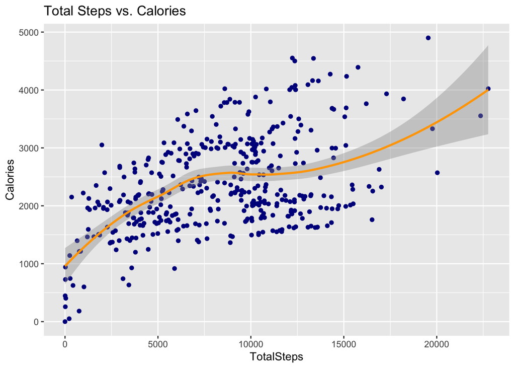

```r
ggplot(data=master_and_sleep, aes(x=TotalSteps, y=Calories)) +
  geom_point(color="darkblue") + geom_smooth(color="orange") + labs(title="Total Steps vs. Calories")
```

The graph illustrates the relationship between the total steps and calories. It aligns with common sense that the more the steps a participant take, the more the calories it burns.

- Does activity relate to sleep time?

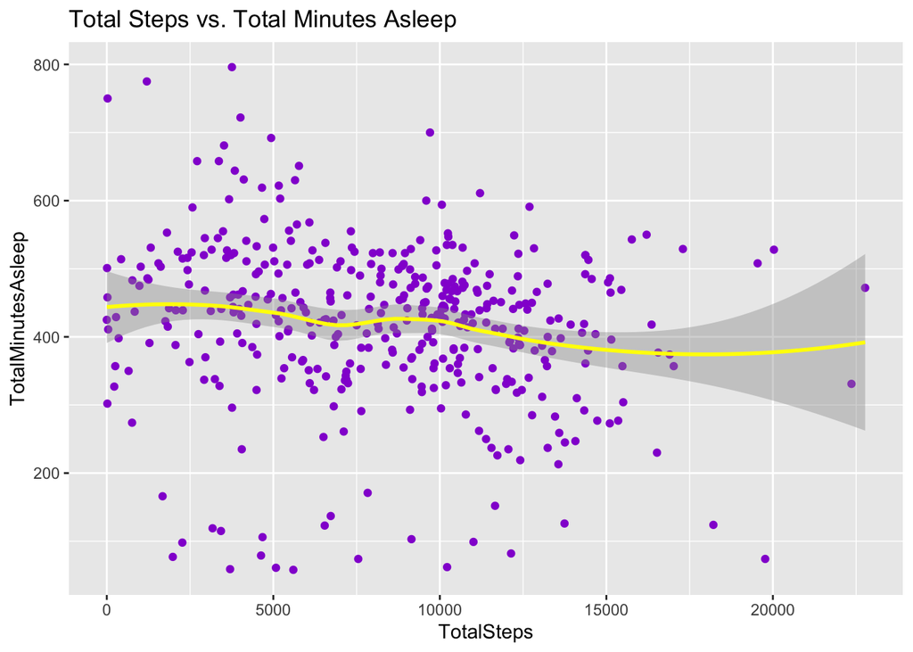

```r
ggplot(data=master_and_sleep, aes(x=TotalSteps, y=TotalMinutesAsleep)) +
geom_point(color="darkviolet") + geom_smooth(color='yellow') +
  labs(title="Total Steps vs. Total Minutes Asleep")
```

The relation does not look too obvious. But we can have a closer look of the quality of sleep.

- Any relation between steps and time in bed awake?

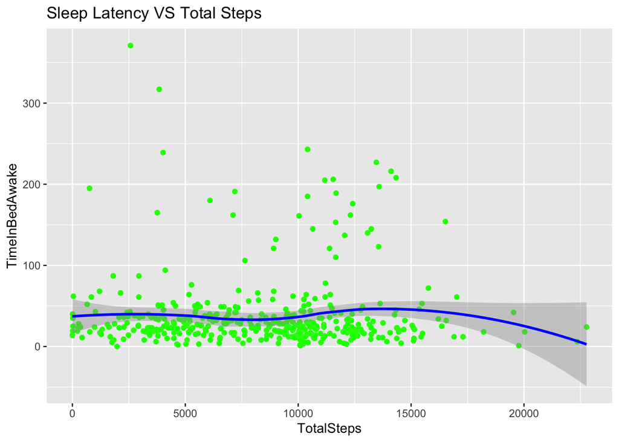

```r
ggplot(data=master_and_sleep, aes(x=TotalSteps, y=TimeInBedAwake)) +
geom_point(color="green") + geom_smooth(color='blue') +
  labs(title="Sleep Latency VS Total Steps")
```

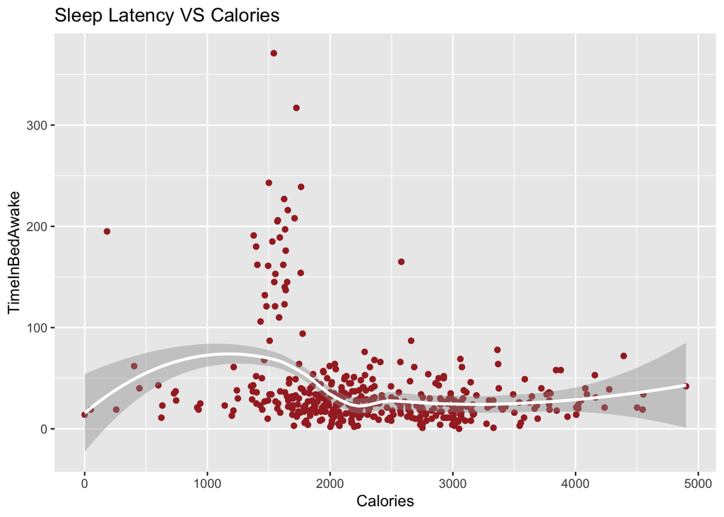

```r
ggplot(data=master_and_sleep, aes(x=Calories, y=TimeInBedAwake)) +
geom_point(color="brown") + geom_smooth(color='white') +
  labs(title="Sleep Latency VS Calories")
```

It might be interesting that while calories burn level is around 1500, the sleep latency varies quite a lot, where observations lie from 100 to over 350. The potential explanation is that 1500 calories is the average energy burn for a person. Hence, we can regard this as the starting point of this analysis and re-run the graph again.

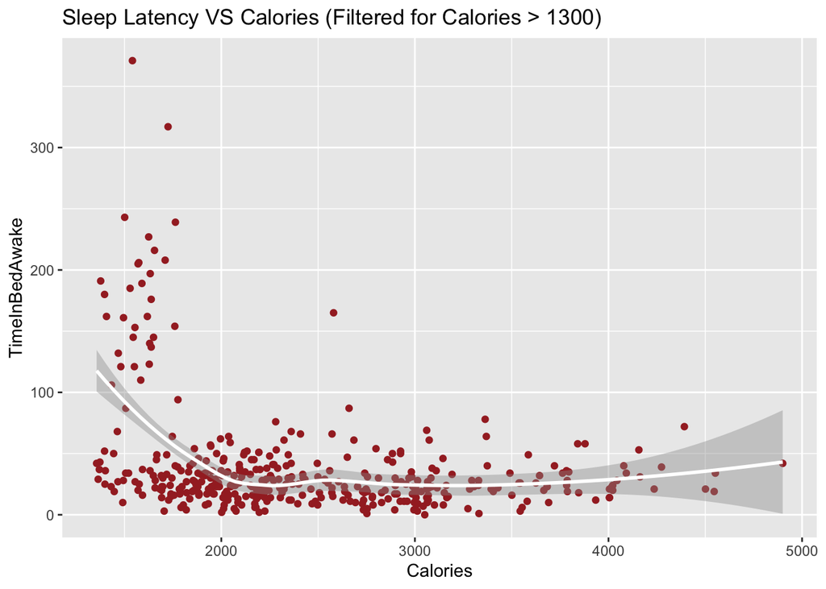

```r
ggplot(data = subset(master_and_sleep, Calories > 1300),
       aes(x = Calories, y = TimeInBedAwake)) +
  geom_point(color = "brown") +
  geom_smooth(color = 'white') +
  labs(title = "Sleep Latency VS Calories (Filtered for Calories > 1300)")
```

In the “Sleep Latency VS Calories burn” graph, we can see that along with the Calories burn increase, the sleep latency tends to stick to low level.

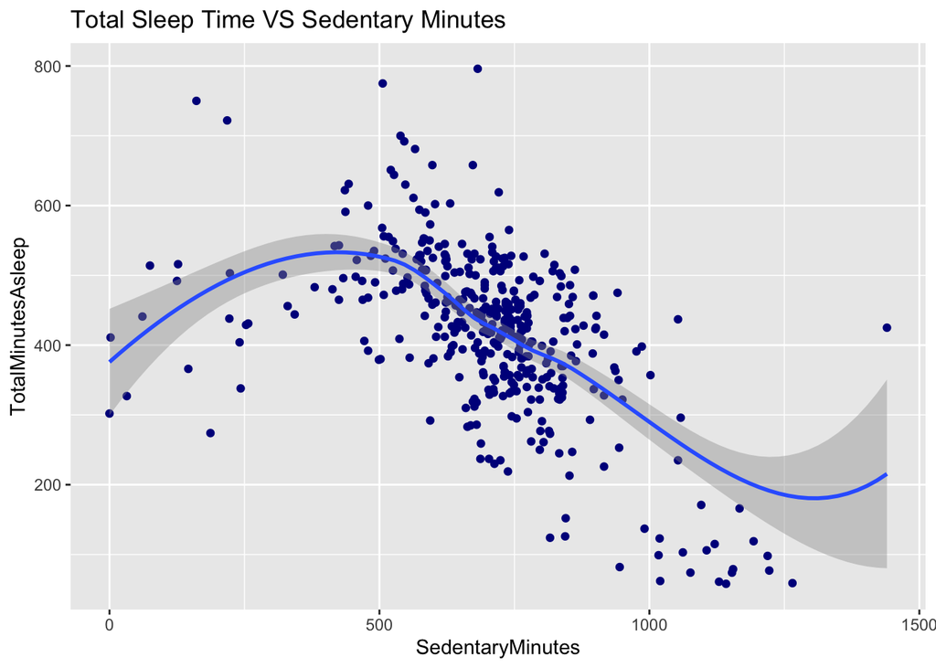

```r
ggplot(data=master_and_sleep, aes(x=SedentaryMinutes, y=TotalMinutesAsleep)) +
geom_point(color='darkblue') + geom_smooth() +
  labs(title="Total Sleep Time VS Sedentary Minutes")
```

In conclusion, I would recommend 4 directions of wellness by using Bellabeat products.

- Increase the incentive for taking more steps (Leaf or Time).
- Put more focus on sedentary time (Time and App).
- Introduce calories intake record to keep track (App).
- Kick start a quality of sleep program (Time and App).

I will choose a rmd file to consolidate the above findings and show the analyses and visualizations along with simple language to communicate with the main stakeholder, Urška Sršen. Guiding questions and images will also be inserted to enhance the comprehensiveness of the presentation.

#### 6. Act

Here are some marketing recommendations:  
- Target customers: exploring the market of social media. As the company has been putting advertisement efforts on the social media platforms, I suggest the company gaining more exposure with regard of promoting engagement of peer group users who have been working well on these platforms, ie collaboration with content creators.  
- Equipping the existing product with new features:  
- App: 1. Invite the famous content creators or celebs to record V.O. and play when the users start the steps recording feature.  
2. Integrate the competition within peer group users on daily steps taken. Ranking features can be introduced and product discounts as prizes may employ.  
3. Implement a tracking program of quality of sleep, which functions as a alarm of calm-down period to promote the balance of activity and sedentary for sleep quality enhancement.  
4. Introduce a calories intake calculation and also meal planning and record to keep track on the food health. This can also complement the peer group competition feature.  
- Leaf: Act as a support of the app in regard of the steps recording feature.  
- Time: Act as a support of the app in regard of the sleep quality record feature.  
- Promotions: - Celeb Branding: invite celebrities in sports or social media content creators to promote the new features.